# Bio of Anthony Gallegos

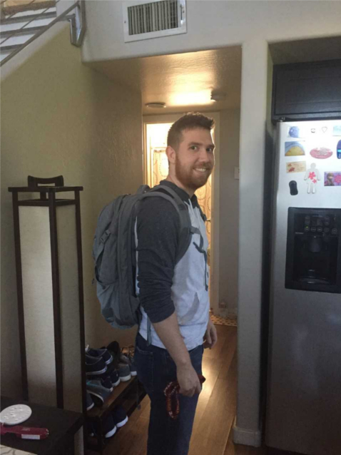

My First Day of Grad School

# About Me

I have a varied background with quite a few interests and experiences. I graduated from ASU in 2008 with a B.S. in Justice Studies, and simulteneously commissioned as an Aviation Officer in the Army National Guard. Shortly after, I worked at The Boeing Company as a technical author/liaison engineer, writing publications and guidence for military aircraft. After about five years of this, I started working at Arizona State University’s Center for Child Well-Being, and enrolled in the M.S. Program Evaluation and Data Analytics program. My hobbies and passions are probably a bit boring to most people, as I am more apt to watch a documentary or read a book than watch most tv shows, and I have been an avid GNU/Linux user for around 15 years.

## My Home Department

[Program Evaluation at ASU](https://publicservice.asu.edu/content/program-evaluation-ms)

## Interest in the Course

As a GNU/Linux user, I am very interested in free and open source software. R is something I’ve seen in multiple environments, but I have never had the opportunity to use. Moreover, my interests are typically centered on social policy, and as a student in the Program Evaluation program this course seems perfectly aligned with my field of study. I would love to learn how to use R to create dashboards that other people can use to easily look at any analysis I have done.

## Three Things About Me

- My wife and I share our home with two cats.
- I used to fly UH-60A/L Blackhawk helicopters.
- I can play about a half dozen woodwind & brass instruments.

## BONUS: Something Weird in my Playlist

[figure not shown]